# Data Manipulation and Visualiation Workshop Midwest Updated February 2023

### Separate and Unite

`Separate` takes apart multiple values that are in the same cell (i.e. same row and column). It will split the values based on a separator (e.g. /, :, ., ).

```r
library(tidyr)
(dates<-fish %>%
  separate(fdate, into= c("Month", "Day", "Year")) %>%
select(2:10))#the column that needs to be separated out, into is the argument to designate the names of the new columns in order of their separation. Can separate many values within a column if needed
```

```
## # A tibble: 4,809 × 9
##     barcode fstation sitetype stratum sdate     stime  Month Day   Year
##       <dbl>    <dbl>    <dbl> <chr>   <chr>     <time> <chr> <chr> <chr>
##  1 11007762        1        0 BWC-S   6/18/2018 08:47  6     18    2018
##  2 11007762        1        0 BWC-S   6/18/2018 08:47  6     18    2018
##  3 11007762        1        0 BWC-S   6/18/2018 08:47  6     18    2018
##  4 11007762        1        0 BWC-S   6/18/2018 08:47  6     18    2018
##  5 11007763        1        0 BWC-S   6/18/2018 09:56  6     18    2018
##  6 11007763        1        0 BWC-S   6/18/2018 09:56  6     18    2018
##  7 11007763        1        0 BWC-S   6/18/2018 09:56  6     18    2018
##  8 11007764        1        0 BWC-S   7/9/2018  07:29  7     9     2018
##  9 11007764        1        0 BWC-S   7/9/2018  07:29  7     9     2018
## 10 11007764        1        0 BWC-S   7/9/2018  07:29  7     9     2018
## # … with 4,799 more rows
```

```r
#glimpse(dates)
```

Separate automatically separates values based on a non alphanumeric value, but you can specify the separator as well. In addition, it also maintains the column type of the original data. If we want to change the resulting columns (Month, Day, and Year), we can specify the `convert` argument which will change the new columns to the most likely column type R determines.

```r
glimpse(dates) #the sdate and fdate columns are characters, maybe we want them to be numeric
```

```
## Rows: 4,809
## Columns: 9
## $ barcode  <dbl> 11007762, 11007762, 11007762, 11007762, 11007763, 11007763, 1…
## $ fstation <dbl> 1, 1, 1, 1, 1, 1, 1, 1, 1, 1, 1, 1, 1, 1, 1, 1, 1, 1, 1, 1, 1…
## $ sitetype <dbl> 0, 0, 0, 0, 0, 0, 0, 0, 0, 0, 0, 0, 0, 0, 0, 0, 0, 0, 0, 0, 0…
## $ stratum  <chr> "BWC-S", "BWC-S", "BWC-S", "BWC-S", "BWC-S", "BWC-S", "BWC-S"…
## $ sdate    <chr> "6/18/2018", "6/18/2018", "6/18/2018", "6/18/2018", "6/18/201…
## $ stime    <time> 08:47:00, 08:47:00, 08:47:00, 08:47:00, 09:56:00, 09:56:00, …
## $ Month    <chr> "6", "6", "6", "6", "6", "6", "6", "7", "7", "7", "7", "7", "…
## $ Day      <chr> "18", "18", "18", "18", "18", "18", "18", "9", "9", "9", "9",…
## $ Year     <chr> "2018", "2018", "2018", "2018", "2018", "2018", "2018", "2018…
```

```r
(dates2<-fish %>%
   separate(fdate, into= c("Month", "Day", "Year"), sep= "/", convert=TRUE))%>%
  select(2:10)#just add the sep and convert arguments here
```

```
## # A tibble: 4,809 × 9
##     barcode fstation sitetype stratum sdate     stime  Month   Day  Year
##       <dbl>    <dbl>    <dbl> <chr>   <chr>     <time> <int> <int> <int>
##  1 11007762        1        0 BWC-S   6/18/2018 08:47      6    18  2018
##  2 11007762        1        0 BWC-S   6/18/2018 08:47      6    18  2018
##  3 11007762        1        0 BWC-S   6/18/2018 08:47      6    18  2018
##  4 11007762        1        0 BWC-S   6/18/2018 08:47      6    18  2018
##  5 11007763        1        0 BWC-S   6/18/2018 09:56      6    18  2018
##  6 11007763        1        0 BWC-S   6/18/2018 09:56      6    18  2018
##  7 11007763        1        0 BWC-S   6/18/2018 09:56      6    18  2018
##  8 11007764        1        0 BWC-S   7/9/2018  07:29      7     9  2018
##  9 11007764        1        0 BWC-S   7/9/2018  07:29      7     9  2018
## 10 11007764        1        0 BWC-S   7/9/2018  07:29      7     9  2018
## # … with 4,799 more rows
```

```r
#we now see that month, day, and year are integers, not characters
#glimpse(dates2)
```

#### Unite

Unite is the opposite of separate. It allows you to combined multiple columns.

```r
#let's recombine month, day, year into Date
(dates3<-dates2 %>%
  unite(Date, Month, Day, Year, sep="/"))#the new column name, first column to combine, 2nd column to combine,3rd column to combine, how you want to separate the values in the column
```

```
## # A tibble: 4,809 × 88
##    site   barcode fstation sitetype stratum sdate  stime Date  ftime pool  lcode
##    <chr>    <dbl>    <dbl>    <dbl> <chr>   <chr>  <tim> <chr> <tim> <chr> <chr>
##  1 <NA>  11007762        1        0 BWC-S   6/18/… 08:47 6/18… 09:02 4     D23.…
##  2 <NA>  11007762        1        0 BWC-S   6/18/… 08:47 6/18… 09:02 4     D23.…
##  3 <NA>  11007762        1        0 BWC-S   6/18/… 08:47 6/18… 09:02 4     D23.…
##  4 <NA>  11007762        1        0 BWC-S   6/18/… 08:47 6/18… 09:02 4     D23.…
##  5 <NA>  11007763        1        0 BWC-S   6/18/… 09:56 6/18… 10:11 4     D24.…
##  6 <NA>  11007763        1        0 BWC-S   6/18/… 09:56 6/18… 10:11 4     D24.…
##  7 <NA>  11007763        1        0 BWC-S   6/18/… 09:56 6/18… 10:11 4     D24.…
##  8 <NA>  11007764        1        0 BWC-S   7/9/2… 07:29 7/9/… 07:44 4     D17.…
##  9 <NA>  11007764        1        0 BWC-S   7/9/2… 07:29 7/9/… 07:44 4     D17.…
## 10 <NA>  11007764        1        0 BWC-S   7/9/2… 07:29 7/9/… 07:44 4     D17.…
## # … with 4,799 more rows, and 77 more variables: gear <chr>, period <dbl>,
## #   rep <lgl>, summary <dbl>, project <chr>, effdist <dbl>, effhr <dbl>,
## #   effmin <dbl>, pwrgoal <dbl>, pwrused <dbl>, volts <dbl>, v_qf <lgl>,
## #   amps <dbl>, a_qf <lgl>, pulses <dbl>, p_qf <lgl>, dutycyc <dbl>,
## #   dc_qf <lgl>, utmzone <dbl>, utm_e <dbl>, utm_n <dbl>, gisgrid <lgl>,
## #   zone15e <dbl>, zone15n <dbl>, gpsmeth <dbl>, gpsacc <dbl>, secchi <dbl>,
## #   s_qf <dbl>, temp <dbl>, t_qf <lgl>, depth <dbl>, d_qf <dbl>, cond <dbl>, …
```

```r
#the default to separate the values in the column is to use the underscore, so you can specify the separator

head(dates3)#The Date column is the same as the original fdate column.
```

```
## # A tibble: 6 × 88
##   site   barcode fstation sitetype stratum sdate   stime Date  ftime pool  lcode
##   <chr>    <dbl>    <dbl>    <dbl> <chr>   <chr>   <tim> <chr> <tim> <chr> <chr>
## 1 <NA>  11007762        1        0 BWC-S   6/18/2… 08:47 6/18… 09:02 4     D23.…
## 2 <NA>  11007762        1        0 BWC-S   6/18/2… 08:47 6/18… 09:02 4     D23.…
## 3 <NA>  11007762        1        0 BWC-S   6/18/2… 08:47 6/18… 09:02 4     D23.…
## 4 <NA>  11007762        1        0 BWC-S   6/18/2… 08:47 6/18… 09:02 4     D23.…
## 5 <NA>  11007763        1        0 BWC-S   6/18/2… 09:56 6/18… 10:11 4     D24.…
## 6 <NA>  11007763        1        0 BWC-S   6/18/2… 09:56 6/18… 10:11 4     D24.…
## # … with 77 more variables: gear <chr>, period <dbl>, rep <lgl>, summary <dbl>,
## #   project <chr>, effdist <dbl>, effhr <dbl>, effmin <dbl>, pwrgoal <dbl>,
## #   pwrused <dbl>, volts <dbl>, v_qf <lgl>, amps <dbl>, a_qf <lgl>,
## #   pulses <dbl>, p_qf <lgl>, dutycyc <dbl>, dc_qf <lgl>, utmzone <dbl>,
## #   utm_e <dbl>, utm_n <dbl>, gisgrid <lgl>, zone15e <dbl>, zone15n <dbl>,
## #   gpsmeth <dbl>, gpsacc <dbl>, secchi <dbl>, s_qf <dbl>, temp <dbl>,
## #   t_qf <lgl>, depth <dbl>, d_qf <dbl>, cond <dbl>, c_qf <lgl>, …
```

### Tidying Data: Pivot data, Factor Recoding, and Synthesis

Tidying data can be really helpful and certain functions in R will require data to look one way, and then you may have to change it to look another way.

If you have data where there are multiple factor entries in the same column and you want to separate each factor into its own column, you can do that with one easy function (`pivot_wider`). Or you can have multiple factor entries in their own columns and you want to combine them in one column (`pivot_longer`). However, this tidying should be done with data that have multiple factors.

```r
#let's create a summary table of the fish data
#we only want 6 species of interest, so get rid of the other 2 species, find the number of observations by species and field station, and turn it into a tibble
fish2<-fish %>%
  filter(Species != "LMBS" & Species != "WRMH") %>%
  group_by(Species, fstation)%>% #group by multiple factors
  summarize(N=n())%>%
  as_tibble() #create a tibble which is a more easily manipulated version of a table in the tidyverse
```

You can `pivot_wider` out one column of data into several columns which may make certain functions doable or make a table more visually appealing.

```r
library(tidyr) #within the tidyr package
#make the tibble spread out to make it easier to read
(observations<-fish2 %>%
  pivot_wider(id_expand=FALSE, names_from= fstation, values_from=N))#id_expand means that if you have "missing data" from columns (no temp data from October-December), you can create empty rows that fill in the missing data (=TRUE) or omit rows with missing data (=FALSE). names_from is the column of variables we want to separate into distinct columns, automatically R will make columns for each of the factors within the column selected. Values_from is the column of data values that will be filled in the new columns' cells
```

```
## # A tibble: 6 × 7
##   Species   `1`   `2`   `3`   `4`   `5`   `6`
##   <fct>   <int> <int> <int> <int> <int> <int>
## 1 BHMW       33    42    39    53    55    69
## 2 BLGL      166   190   168    61    20   143
## 3 CNCF       88   263   215   270    53   364
## 4 ERSN      101   178    59    99   127    96
## 5 FWDM       52    82   104   212   185   223
## 6 GZSD      141   126   166   175    93   298
```

Now we will use several other `tidyverse` functions to change the look of the table we have made. We can use different renaming functions and factor renames to alter our text. These functions do not have to be used after a `group_by` and `summarize` combo, they can be used at any step of tidying data.

```r
#let's rename the columns
    (observations2 <- observations %>% dplyr::rename(`Pool 4`= `1`, `Pool 8`=`2`, `Pool 13`=`3`, `Pool 26`=`4`, `Open River`=`5`, `La Grange Pool`=`6`)) #(New name = old name)
```

```
## # A tibble: 6 × 7
##   Species `Pool 4` `Pool 8` `Pool 13` `Pool 26` `Open River` `La Grange Pool`
##   <fct>      <int>    <int>     <int>     <int>        <int>            <int>
## 1 BHMW          33       42        39        53           55               69
## 2 BLGL         166      190       168        61           20              143
## 3 CNCF          88      263       215       270           53              364
## 4 ERSN         101      178        59        99          127               96
## 5 FWDM          52       82       104       212          185              223
## 6 GZSD         141      126       166       175           93              298
```

```r
library(forcats) #within the forcats package (deals with factors)
#lets also add sum column and row for totals
observations2<-observations2%>%
  # ungroup(observations2)%>% #need to ungroup the data to manipulate it. It is currently grouped because the ojbect "observations2" was created down the line from "fish2" which was a result of our group_by & summarize combo. This was only for older versions of dplyr and R
    mutate(Total=`Pool 4`+`Pool 8`+`Pool 13`+`Pool 26`+`Open River`+`La Grange Pool`) %>% #use mutate to create a new column of data called "Total" and we will add all of the numbers from each field station together
    mutate(Species= fct_recode(Species, #Now use mutate to rename the "factors" which are the species names. Here, we use fct_recode (factor recode)
                             "Bullhead Minnow" = "BHMW", #New name = old name
                             "Bluegill" = "BLGL",
                             "Channel Catfish" = "CNCF",
                             "Emerald Shiner" = "ERSN",
                             "Freshwater Drum" = "FWDM",
                             "Gizzard Shad" = "GZSD")) #column for each species
```

```r
#library(forcats)
observations2 %>%
  mutate(Species= fct_collapse(Species,
                             `Forage Fish` = c("Bullhead Minnow", "Emerald Shiner", "Gizzard Shad"), #name of new category, concatenated factors that will be in new category
                             `Omnivore` = c("Channel Catfish"),
                             `Invertivore` = c("Bluegill", "Freshwater Drum")))
```

```
## # A tibble: 6 × 8
##   Species     `Pool 4` `Pool 8` `Pool 13` `Pool 26` `Open River` La Gran…¹ Total
##   <fct>          <int>    <int>     <int>     <int>        <int>     <int> <int>
## 1 Forage Fish       33       42        39        53           55        69   291
## 2 Invertivore      166      190       168        61           20       143   748
## 3 Omnivore          88      263       215       270           53       364  1253
## 4 Forage Fish      101      178        59        99          127        96   660
## 5 Invertivore       52       82       104       212          185       223   858
## 6 Forage Fish      141      126       166       175           93       298   999
## # … with abbreviated variable name ¹`La Grange Pool`
```

```r
#other factors not mentioned will stay the same
#we can see that the rows for the new factors don't combine together, and that's because this tibble is created based on the grouping variables we first described. We would need to redo the tibble creation to make the factors actually collapse with one another. Do factor collapse before manipulating your data if you want to summarize/group by the new categories
```

As we can see from the above chunks of code, `mutate()` has many roles. From creating new data columns, to renaming factors, to changing column names, as well as many we did not cover. The commonality with `mutate()` functions is that we specify the `mutate()` function first, provide a column of data we want to manipulate, and then specify another type of function. Our column can be a new column we make or it can be overwriting a column.

If you have multiple columns that you want to combine into one column, you can do that with the function pivot_longer. It is the opposite of pivot_wider.

```r
#Let's take all of the site columns we made using pivot_wider, and make them into a single column. Doing so will assign every site to each individual. The NAs mean that that individual was not in that site.

obs3<-observations2 %>% #pipe straight away
  select(-Total)%>% #remove the total column since we don't need to have that gathered in our dataset. Select with a minus sign in front of the column you don't want will deselect the column
pivot_longer(names_to="Site", values_to="N", 2:7 ) #names_to is the new column you are making as the "names" or ID for whatever data you want, so we want to make site into one column. Values_to is the information from the multiple columns you want to combine. This value will be a new column with whatever name you give it. the numbers are the numbers of the columns you wish to combine together. Here we are taking all of the site columns we made whitch are columns 2 through 7. The : means "through"
```

We will now take our second break to practice manipulating data with `tidyr`, `forcats`, and `dplyr` functions.

# Exercise 2

You will use the 2008-2018 North American Breeding Bird Survey data for Mexico along with the RouteData file containing environmental and route specific details of the survey to answer the following questions. You will use the tools we have covered so far within `tidyverse`. You will have approximately 30 minutes to complete the exercises and ask questions. If you finish early, explore the data on your own.

Task 1: Join the 2 datasets by the StateNumbers, Route, and RunDate variables.

```r
 #read in the datasets


#use a join function, use c() around multiple column names when joining them
```

Task 2: Separate the RunDate column into Month, Day, and Year columns.

```r
#separate
```

Task 3: Which species has the highest total number of sightings in the entire dataset and how many sightings are there? How many species have 10 or fewer sightings?

```r
#Highest

  #pivot_longer all stop columns


#group by species


#summarize sightings (of the new column that was pivot_longered)


#highest sightings: arrange



#10 or fewer sightings: filter
#use the same code as above for the most part
```

Task 4 Challenge: Using only data where temperature was collected in Celsius, create a table of the total number of sightings for each genus in 2018 by State. Separate the table so each state is in its own column and labeled as “State_x” where x is the number of the state in the dataset (e.g. State_6). Which state has the greatest number of Anas species sightings?

Hint: Use functions filter, group_by, summarize, separate, pivot_longer, pivot_wider, rename

```r
#filter for Celsius and year


#separate ScientificName to get genus and species


#pivot_longer all stops


#group by genus and state number


#summarize to get total number of sightings


#pivot_wider by state Number

#rename columns


#filter for Anas
```

# Visualization

We will now move from manipulating the data to visualizing the data. However, we will also call on some of the functions we used in the first half of this workshop. We will work in `ggplot2` package to visualize our data.

### Introduction

`ggplot2` is a graphing package from the tidyverse. It is incredibly powerful for creating publication-quality graphics. `ggplot2` should basically be used at all times unless you’re trying to do just quick graphing for basic visualization or mapping (use `spplot`, `Tmap`, or `Leaflet` for maps). There are numerous types of graphs you can create, and you can add onto your code easily to make the graphics more complex. You can even pipe (%>%) directly from `dplyr` into `ggplot2`. However, instead of continuing with the pipe throughout, you switch to using `+` within `ggplot2` to add more code.

### Basics

`ggplot2` builds on code. So you keep code and if you want to add a legend, axis labels, colors, etc., you use a `+` and make a new code line. It reads nicely when you type everything out.

The syntax for graphing in ggplot is to specify the dataset and variables from that dataset within the `ggplot()` function. No figure will be created with only the `ggplot()` function, a geometry for the plot must be specified in a second line of code. Geometries can be points, lines, histograms, bars, violins, boxes, etc. And you can have multiple geometries in one figure (e.g. lines and points).

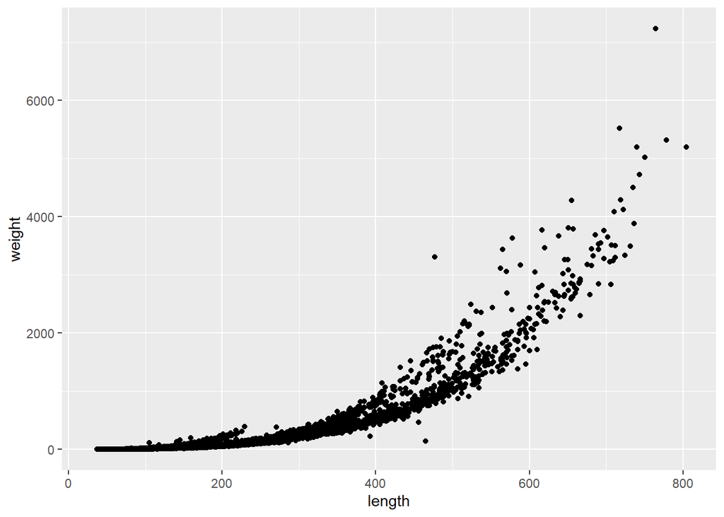

```r
#load the ggplot2 package
library(ggplot2)
library(dplyr)
library(readr)

#reload the data or the following code will not run. We revert back to original column names that we changed in the previous half of the workrshop.
fish<-read_csv("./2018 LTRM data.csv", col_types= list(weight =col_double(), fstation = col_factor()))
fish<-filter(fish, fishcode!="LMBS" & fishcode !="WRMH") #remove the two species we aren't interested in

#the geom command selects type of graph geom_point tells R to show the data as points. Graph weight and length
ggplot(fish, aes(length, weight))+ #dataset, aes(x,y)
  geom_point() #this means your geometry for the plot is points (you can have lines, boxplots, bars, columns, etc)
```

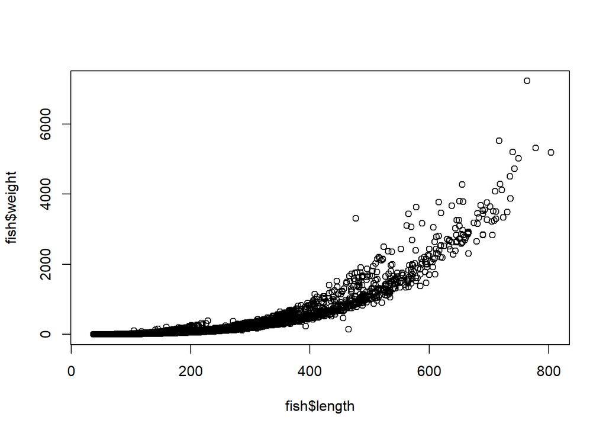

```r
plot(fish$length, fish$weight) #base R plotting. UGLY
```

NOTE: For purposes of this workshop it does not matter if the data is specified in the `ggplot()` function or in the `geom_x()` function as long as the dataframe is provided and the variables you are mapping are provided in the `aes()` argument. The code provided below will provide the same figure. When you delve into more complex figures, sometimes you may want to bring in data from multiple datasets. In this scenario, specifying the data in the `ggplot()` function tells the `geom_x()` function where to pull the data from while specifying the data in the `geom_x()` function will allow you to create different geometries using different datasets.

```r
ggplot(fish, aes(length, weight)) +
  geom_point()

ggplot()+
  geom_point(data = fish, aes(length,weight))
```

### Background

I personally hate the grey, lined background, so I use the following function to make the background blank. However, this code will apply to all figures in your R session that you produce. If you want a grey or different colored background for some figures, you do not need to run this code. Additionally, when working in RMarkdown, this line of code only applies to the code chunk where it was written when you knit the document to make .docx, .pdf, or .html files.

```r
library(ggthemes) #for theme_set function
theme_set(theme_few()) #makes background white, instead of gray. Must have ggthemes package loaded!
```

If you want to make the background change for only one graph, you can use the following code in a single plot. In using this code, you can make the background any color you want from hotpink to chartreuse. Notice that the grid lines are still apparent if you change to a color other than white (can also use `element_blank()`) unless you add in the panel grid code.

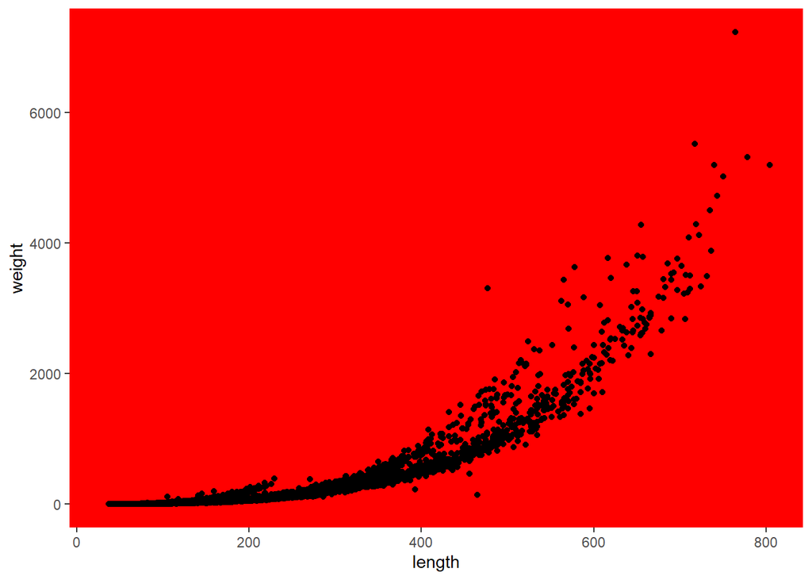

```r
ggplot(data=fish,mapping = aes(length, weight))+
  geom_point() +
  theme(panel.background = element_rect(fill="red"), panel.grid.major = element_blank(), panel.grid.minor = element_blank()) #change the background color to red and get rid of grid lines
```

### Aesthetics

We can alter essentially every aspect of a graph (color, shape, text size, point size, lines, legends, etc.). There are two ways we can manipulate the graph aspects: global and aesthetic (`aes`) parameters. Global parameters affect the entire plot uniformly, while aesthetics affect only the objects in the plot you are interested in manipulating with the code. Using `aes` (aesthetics) allows you to do a lot more interesting things with the data as well.

Here, we will alter the plot’s point’s color, shape, and size using global parameters.

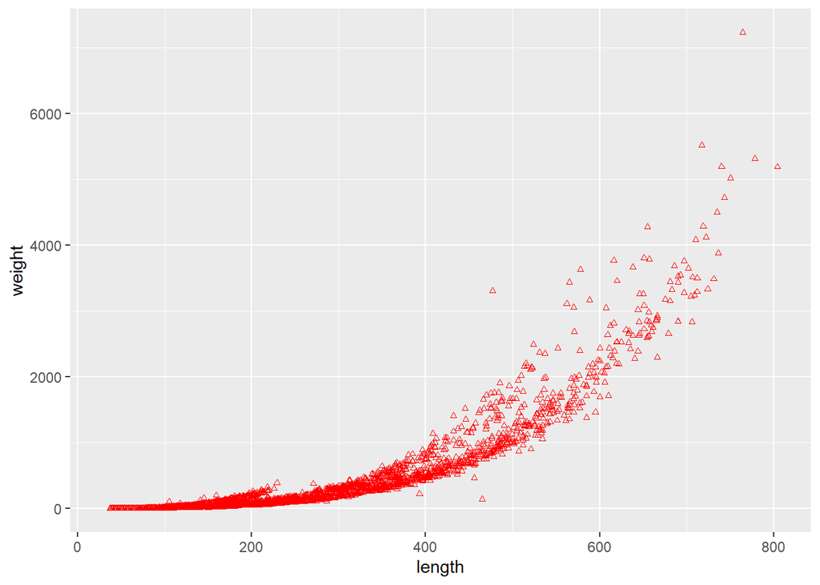

```r
#any specifications in the aes command will be specific to that part of the plot, but everything outside of the aes statements will apply to all of the plot
ggplot(data=fish,mapping = aes(length,weight))+ #data= and mapping = are not necessary to make the plot, but may help keep information more clear for your own sanity
  geom_point(color="red", shape=2, size=1) #make the color of the points red, change the size and the shape
```

Here we changed the size, shape, and color of the points using global parameters which means that all of the points were equally affected. But what if we wanted to change the geometries by factor? For example, make the color of the points reflect another variable?

Next, we are going to change the color of the points based on the species.

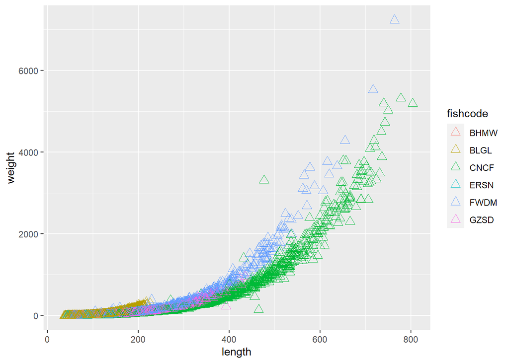

```r
#any specifications in the aes command will be specific to that part of the plot, but everything outside of the aes statements will apply to all of the plot
ggplot(data=fish,mapping = aes(length, weight))+
  #make the color of the points change with species of fish
  # within the geom_points command you can customize the points
#you can also use aes statements within the geom statements to pull in different parts of datasets into the same plot (for example, the fishcode factor)
  geom_point(shape=2, size=3, aes(color=fishcode)) #notice how shape and size are outside of aesthetics, because they are still global parameters, so they will affect all of the points equally. But now color will change based on fishcode
```

The colors of our points change based on data for species. The species variable is a factor, which allows you to have discrete color categories. You can hand pick the colors used for the points too. We also see that `ggplot2` automatically made a legend. This legend can be altered in position, text, etc which we will do later. You can put any of the parameters in the aesthetics to change the data points. For examples, we could change the size, shape, or transparency (`alpha`) of the points.

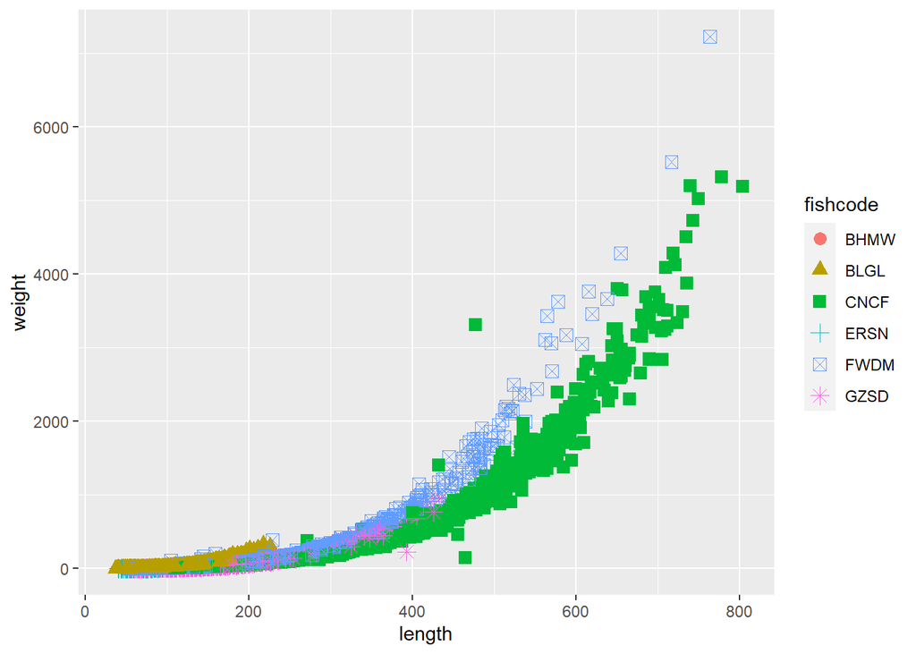

```r
#any specifications in the aes command will be specific to that part of the plot, but everything outside of the aes statements will apply to all of the plot
ggplot(data=fish,mapping = aes(length, weight))+
  #make the color AND shape of the points change with species of fish
  geom_point(size=3, aes(color=fishcode, shape=fishcode)) #notice how size is outside of aesthetics, because it is still a global parameter, so it will affect all of the points equally. But now color AND shape will change based on the species
```

### Stats

Some of the geometries within `ggplot2` automatically create the stats needed for the figure. For example, the fish dataset does not contain count data, but we can still make a barplot. We don’t need to calculate the `nobs()` ourselves before plotting, because using the `stat_count()` automatically does this for us.

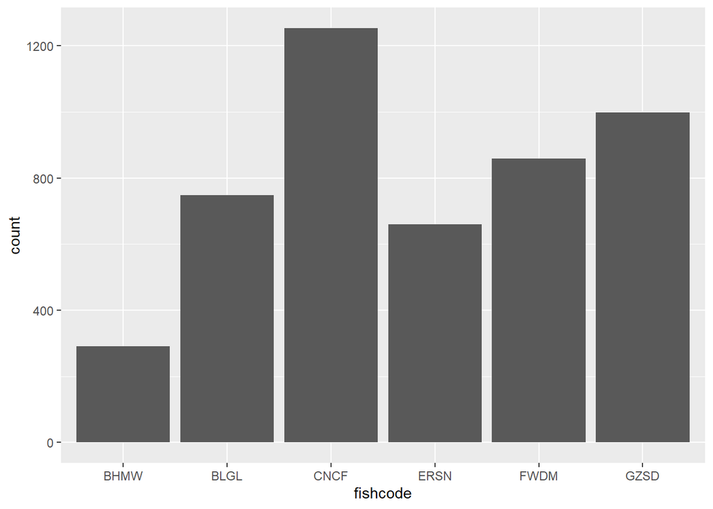

```r
ggplot(fish, aes(fishcode))+ #notice we only have one FACTOR variable within aes
  stat_count() #specify stat_count rather than a geometry
```

You can change these stats if you want them to show the data a different way as well, perhaps proportion is what you want to display. Notice we now use the `geom_bar` rather than `stat_count`.

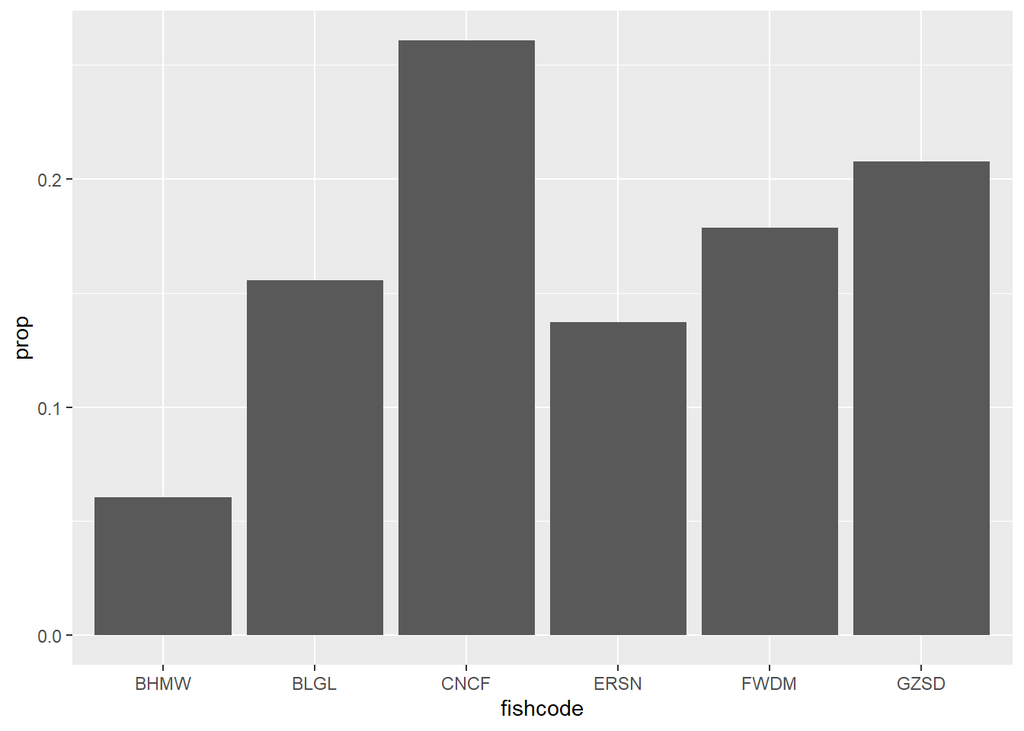

```r
ggplot(fish, aes(fishcode))+ #again, we only have one FACTOR variable within aes
  geom_bar(aes(fishcode, ..prop.., group=1)) #use geom_bar with the aes ..prop.. to create a proportional barplot, fishcode is the x variable, ..prop.. to get proportions, group=1 because we want the bars to represent the proportion of all fish in the data
```

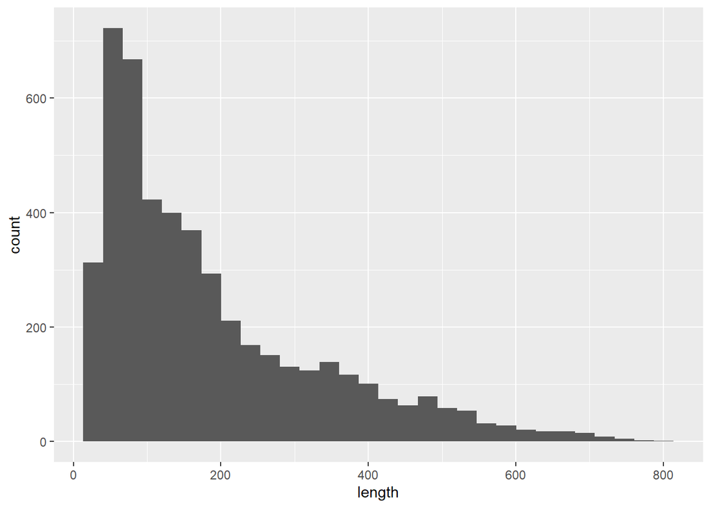

```r
ggplot(fish, aes(length))+ #specify only one CONTINUOUS variable
  geom_histogram()
```

You can change binwidth for your histograms which smooth the data or make it blockier. Here we will create a binwidth of 10 so each 10 mm size class is counted in the data.

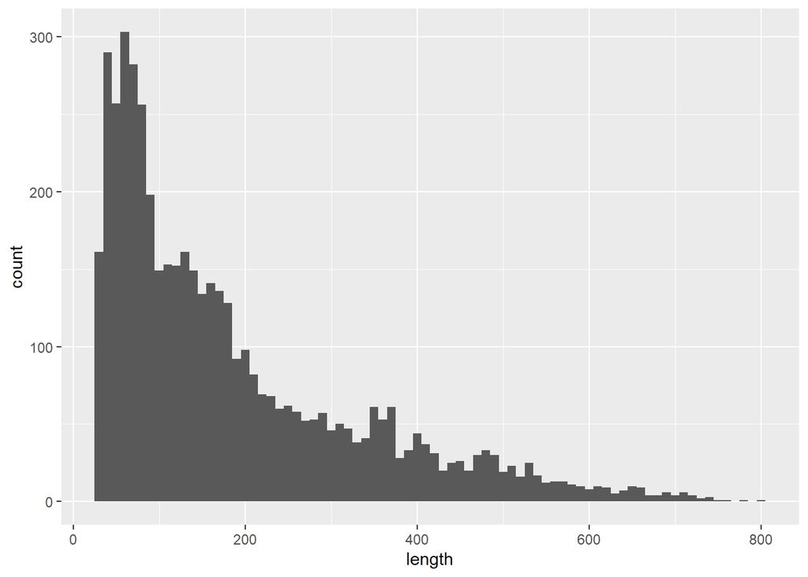

```r
ggplot(fish, aes(length))+
  geom_histogram(binwidth = 10) #Add binwidth argument
```

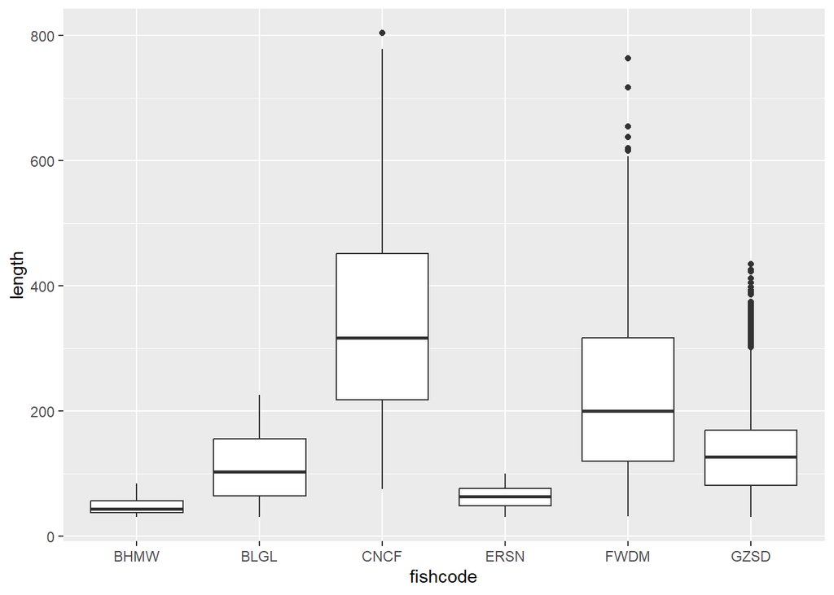

```r
ggplot(fish, aes(fishcode, length))+ #here we have two variables. One must be a factor and the other on a continuous scale
  geom_boxplot() #specify the boxplot geometry
```

### Position

You can arrange the position of your data in multiple ways. For barplots, this is really handy for comparing data.

- identity- overlapping, all raw count data/number of observations start on x-axis
- jitter- overlapping, but able to see part of all data as they are off-set from one another (most often used with `geom_point`)
- stack- stacked raw count data
- fill- stacked proportion
- dodge- side by side raw count data

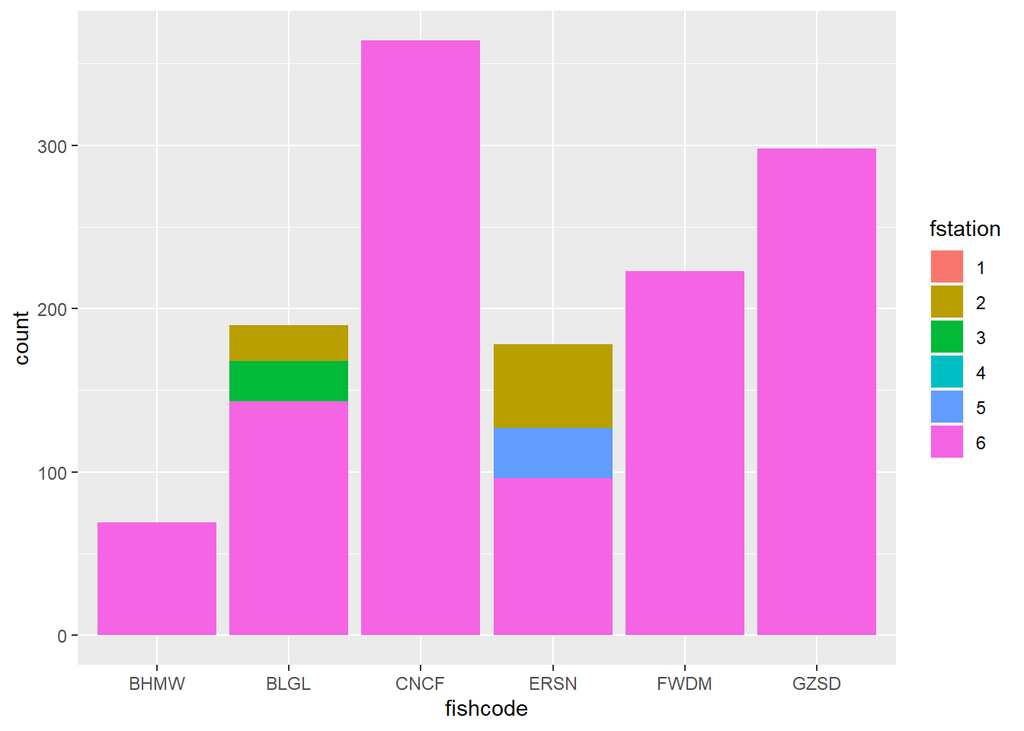

```r
ggplot(fish, aes(fishcode, fill=fstation))+
  geom_bar(position="identity") #overlapping data of raw counts, data are not visible because they overlap bars
```

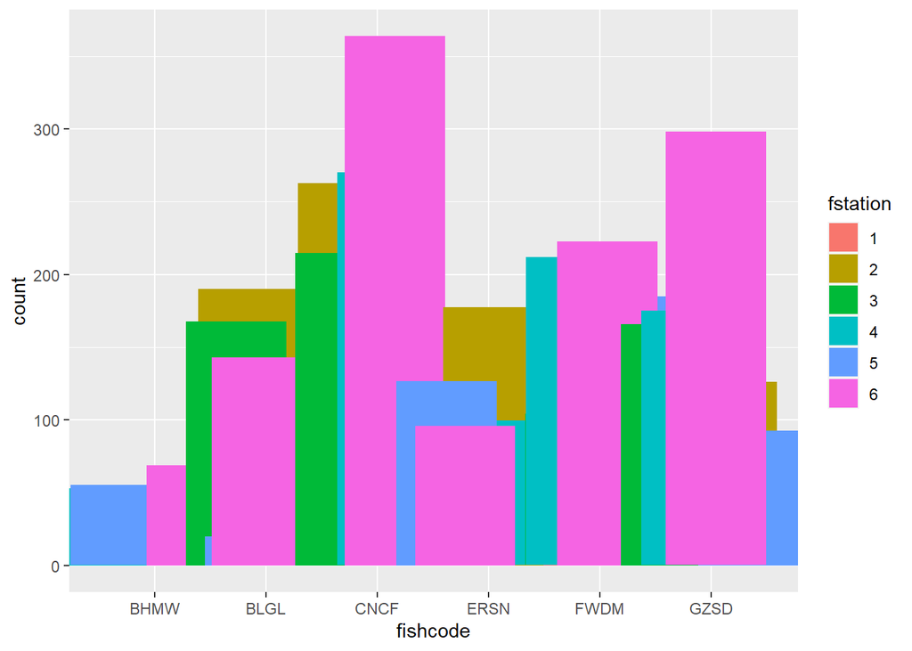

```r
ggplot(fish, aes(fishcode, fill=fstation))+
  geom_bar(position="jitter") #overlapping data of raw counts, data are visible because they are offset
```

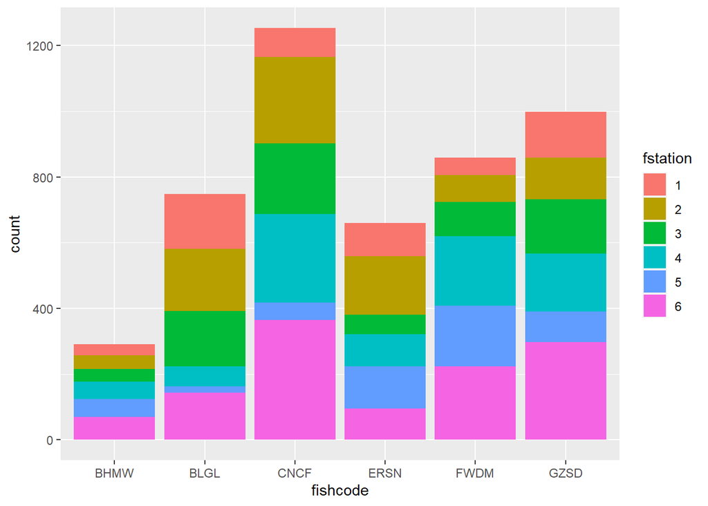

```r
ggplot(fish, aes(fishcode, fill=fstation))+
  geom_bar(position="stack") #stacked data of raw counts, data are all visible because they are stacked bars
```

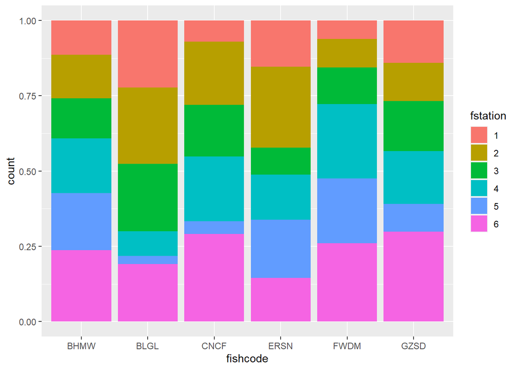

```r
ggplot(fish, aes(fishcode, fill=fstation))+
  geom_bar(position="fill") #stacked data of proportions
```

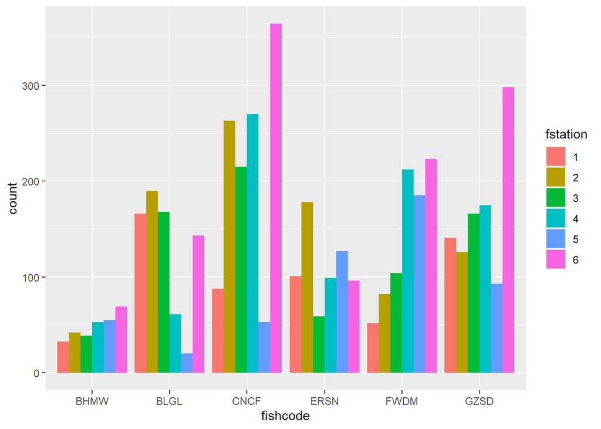

```r
ggplot(fish, aes(fishcode, fill=fstation))+
  geom_bar(position="dodge") #side by side raw counts, this one is the most readily comparable
```

### Basic Themes

Now that we can put data into plots and customize the points and lines, let’s customize the rest of the plot. The argument `theme` allows you to customize the appearance of many aspects of the plot including legends and titles. `theme` is its own function and you add more arguments to `theme` by using commas. Here, we will start with some basic text themes and add labels to the figure.

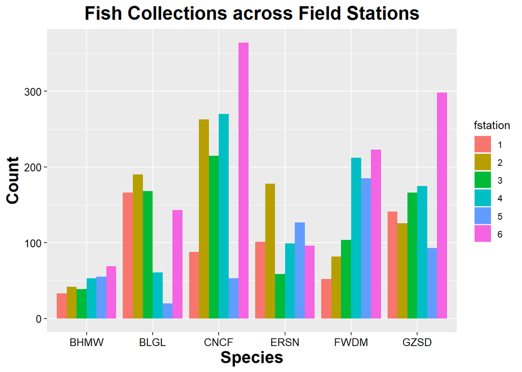

```r
fish$fstation<-as.factor(fish$fstation) #coerce the fstation variable into a factor permanently
ggplot(fish, aes(fishcode, fill=fstation))+
  geom_bar(position="dodge")+ #dodge for side-by-side comparison
  ylab("Count")+ #add a y-axis title
  xlab("Species")+ #add a x-axis title
  ggtitle("Fish Collections across Field Stations")+ #add a plot title
theme(
    axis.title.x = element_text(size=16, face="bold"),#make x axis title bold and size 16
    axis.title.y = element_text(size =16, face="bold"),#make y axis title bold and size 16
    plot.title = element_text(size=18, face="bold", hjust=0.5), #make plot title bold, size 18, and horizontally adjust to center of figure
    axis.text = element_text(size=10, color="black")#change text on axes to be size 10 and black rather than the default grey
    )
```

We will now take a break to complete exercises using basic `ggplot2` functions.

# Exercise 3

We will use `ggplot2` to create basic visualizations with the bird count data.

```r
#read in bird data

#read in routedata

#join data
```

Task 1: Create a boxplot of the starting temperature by State for temperatures only in degrees C. Hint: you may need to coerce state number to a different variable class.

Do any of the data points stand out? Remove any outlandish data points and plot again.

```r
#filter for Celsius



#plot temperature by state, coerce state to factor. Factors always on x-axis

#boxplot geometry




#use filter to remove outlandish datapoints in temperature



#replot
```

Task 2: Using the vetted temperature data from the last task, create a scatterplot of the Starting and Ending Temperatures. Change the color of the points using global parameters and the shape of the points using aesthetic parameters.

```r
#use same saved data from last task (where the outlandish data points were removed) or repeat code


#plot starting and ending temperatures

#point geometry: global color, aesthetic shape
```

Task 3: Create a barchart of the number of sightings by species for all counts greater than 0 within State 7, route 17, stop 48. Hint: You will need to use dplyr functions to summarize the data before plotting and use stat=“identity”.

```r
#filter for state and route


#group by species


#summarize (sum) by stop 48


#filter for counts greater than 0

#barchart geometry using stat="identity"
```

Task 4: Using the same plot as Task 3, change the x and y axes titles, create a plot title, and change the basic text themes (color, size, face) for the x and y axes and the title.

```r
#copy code from above


#x-axis title


#y-axis title


#plot title


#themes function
#axis titles color, size, face

#plot title color, size, face
```

# Advancing GGplot2 Toward Publication Quality Figures

We will continue using `ggplot2` to discuss several aspects of figure aesthetics that can be implemented toward creating publication quality figures.

### Color

Color is a major component of visualizing data. Color choices matter greatly to correctly visualize your data and make the data understandable for the reader/interpreter. There are many plots that incorrectly show data because of the choice of color. We have looked a little bit at color previously by changing the color of points based on aesthetic and global parameters as well as a factor. However, we did not discuss the families of colors or how to select different colors. Before, R automatically chose a color palette to fill in the bars, but we can also select the colors we want.

Some fundamentals of color choices:

1. If you have a continuous scale of data where the data is unidirectional, perhaps precipitation from 0 to 100mm, you want to show the data as one color family on a figure. Here, the values of the data closest to 0 should be a lighter (or darker) shade of the color and the values of the data closest to 100 should be a darker (or lighter) shade of the color.
2. If you have a continuous scale of data where the data is multidirectional, maybe you have negative and positive values with 0 as the center, you want to show the data as similar color families but with two different hues. One hue would be for negative values and one would be for positive values.
3. If you have related factor data, maybe low, medium, and high values, you want to show the data as one color family. Choose a lighter shade for low, medium shade for medium, and darker shade for high.
4. If you have unrelated factor data, maybe different habitats wildlife were located in, you want to show the data as multiple color families. However! these colors should not clash to create a very ugly figure.

You should always keep in mind colorblindness when selecting colors as well. NEVER put red and green on the same figure if you can help it. The R Color Brewer and online color selectors can help you with colorblind-friendly color palettes.

We can select colors by naming palettes, naming individual colors, creating palettes using hex codes (#000000), or using R color brewer. See more information [here](http://www.sthda.com/english/wiki/colors-in-r) or [here](https://bookdown.org/rdpeng/exdata/plotting-and-color-in-r.html).

Our first example with color looks at the outline vs fill different figures. Fill is the color within the chart type while color is the color of the line around the chart type. So, for barcharts you have fill which is coloring the bar and color which is the line around the bar

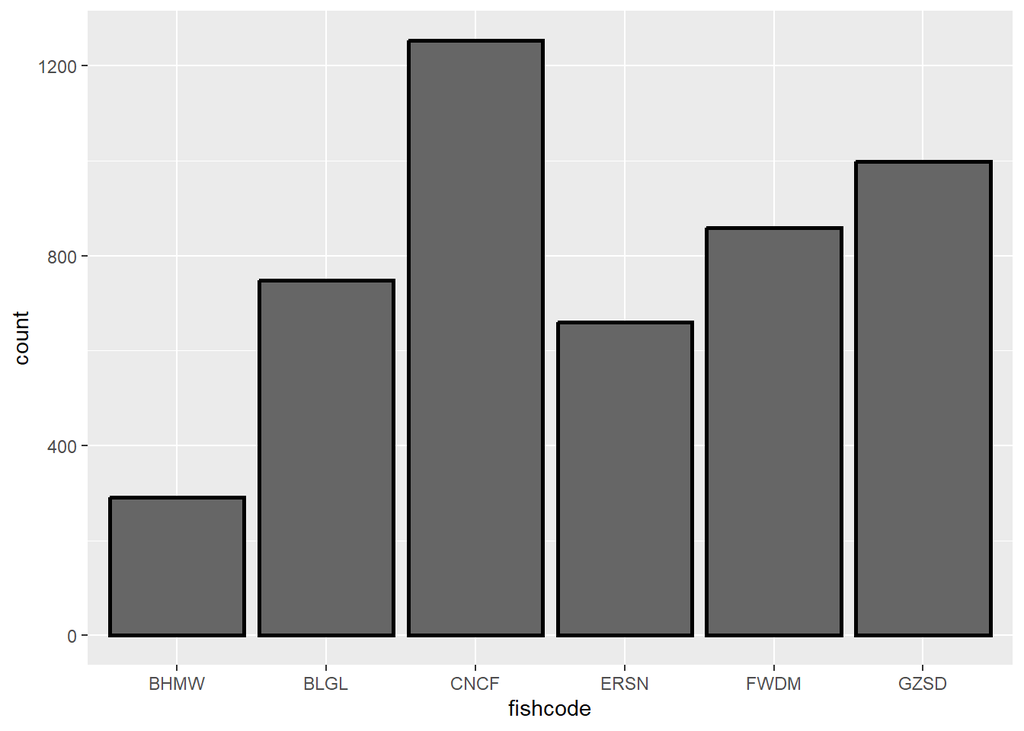

```r
ggplot(fish, aes(fishcode, fill=fstation))+
 geom_bar(color="black", size=1, fill="grey40", position="dodge") #color is the line around the bar, fill is coloring in the bar, size changes the width of the line around the bar
```

The same fill and color principles can be applied to boxplots and other types of plots as well such as scatter if there are open points which are shape numbers 21-25.

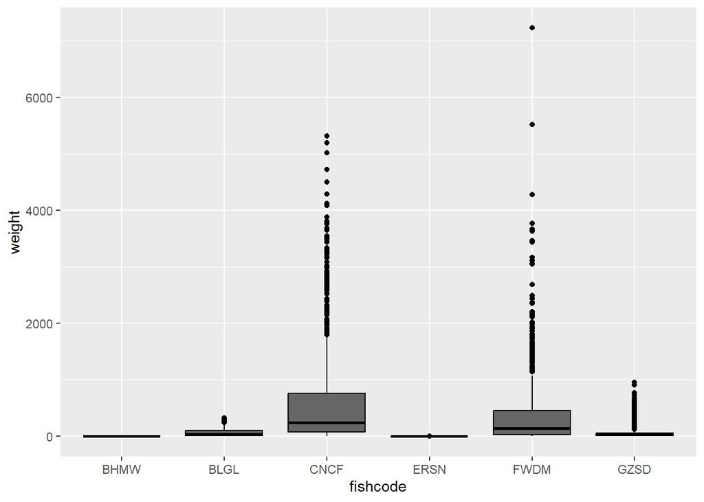

```r
ggplot(fish, aes(fishcode, weight))+
  geom_boxplot(color="black", fill="grey40") #change colors for the color (line) argument and the fill argument
```